# Ficha de Información Metropolitana

Universidad Autónoma Metropolitnana

Lic. Martínez Rodriguez, Alvaro[^1]

Lic. Pérez Victorino, Leonardo[^2]

La ficha de información metropolitana es una herramienta valiosa para la planificación territorial en zonas metropolitanas (ZM). Proporciona información censal en diferentes formatos, como gráficos, tablas y mapas, tanto de los Censos de Población y Vivienda, 2020 (CPV2020) como de los Censos Económicos de 1999, 2004, 2009, 2014 y 2019. Ambos publicados por el Instituto Nacional de Estadística y Geografía (INEGI).

## Información general de la Zona Metropolitana de Celaya

Según (Sedatu 2018), la zona metropolitana se define como un área urbana que consta de una ciudad principal y su zona conurbada. Las zonas metropolitanas se caracterizan por tener una alta densidad de población y estar interconectadas por vías de transporte y comunicación. La zona metropolitana de Celaya, se localiza en Guanajuato. y esta compuesta por 4 municipios, que se muestran a continuación:

| Nombre | Clave |
| --- | --- |
| Celaya | 11007 |
| Comonfort | 11009 |
| Cortazar | 11011 |
| Villagrán | 11044 |

Municipios de la zona metropolitana

Además, se presenta un mapa de la zona metropolitana:

[interactive chart not shown]

A continuación se presentan algunos datos generales sobre esta zona:

- Zona Metropolitana:Celaya
- Número de municipios: 4
- Población total: 767,104
- Superficie de la ZM: 1,493 [m^2]
- Densidad poblacional: 513.8 [1/m^2] Hab/Km^2.
- Grado promedio de escolaridad: 9.01

## Información sociodemográfica

La estructura de población de la zona metropolitana de Celaya se presenta en la una piramide poblacional ya que permite obtener una visión general de la distribución de la población por género y edad:

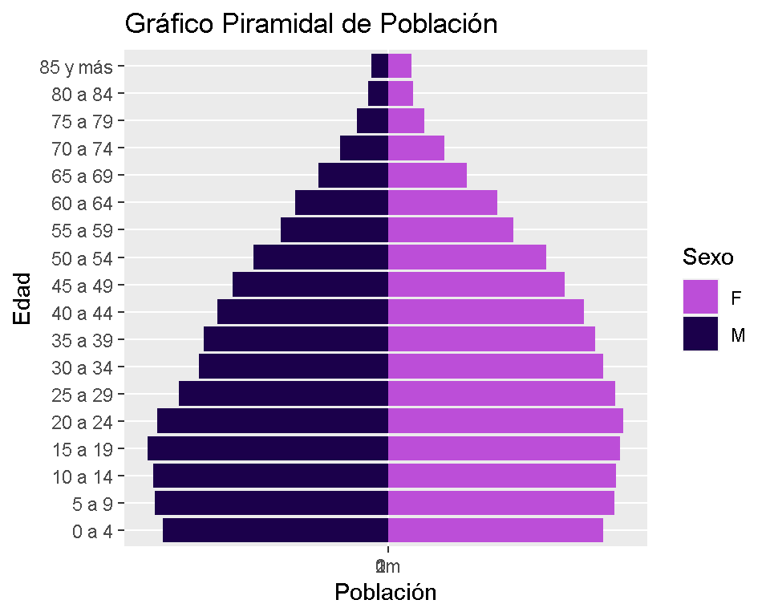

En el siguiente mapa se observa como se distribuye la población sobre la región:

[interactive chart not shown]

### Grupos de población

- Población total respecto al país: 1%. Este valor indica el peso poblacional de la zona metropolitana en relación con la población total de México.
- Población Masculina: 48%
- Población Femenina: 52%
- Relación M-F: 93.102. Este valor indica la proporción de hombres por cada mujer en la zona metropolitana.

### Socioeconómicos

La población en terminos de la poblacioón economicamente activa esta descrita por:

- Porcentaje de población de 12 años y más económicamente activa: 49%
- Porcentaje de población de 12 años y más no económicamente activa: 30% `

### Educación

La educación de la zona metropolitana esta caracterizada por los siguientes estadísticos:

- Porcentaje de población de 15 años y más sin escolaridad:4%
- Porcentaje de población de 15 años y más con al menos un grado aprobado en primaria: 70%
- Porcentaje de población de 15 años y más con educación básica completa: 22%
- Porcentaje de población de 15 años y más con secundaria o equivalente incompleta:2%
- Porcentaje de población de 18 años y más con al menos un grado aprobado en educación media superior: 30%

### Salud

La situación de la afiliación a algún servico de salud es la siguiente:

- Porcentaje de población afiliada a servicios de salud: 77%
- Población sin afiliación a servicios de salud:174606

### Indicadores de desarrollo

IDH es un indicador elaborado por el Programa de Naciones Unidas para el Desarrollo (PNUD), este busca medir la calidad de vida, así como el progreso socioeconómico de cada entidad y municipio; El cálculo del Índice de Desarrollo Humano se realiza a partir de las tres variables: esperanza de vida, educación e ingreso per cápita.

- Muy Alto - IDH mayor de 1.
- Alto - IDH entre 0.80 a 1.
- Medio - IDH entre 0.50 y 0.80.
- Bajo - IDH entre 0 y 0.50
- Muy Bajo - IDH menores a 0.
- El promedio del IDH en 2020 para la zona metropolitana es de 0.723 según datos del PNUD.

El IM es un índice construido por el consejo Nacional de Población (CONAPO). Este índice considera 4 dimensiones estructurales para su construcción: vivienda, ingreso, educación y distribución de la población. El indice se puede ubicar en 5 estratos designados por la ténica de estratificación de Dalenius-Hodges..

Por último, el IRS es construido por el Consejo Nacional de Evaluación de la Política de Desarrollo Social, CONEVAL, este índice incorpora indicadores de educación, de acceso a servicios de salud, de servicios básicos y tiene como finalidad ordenar los municipios según sus carencias sociales. Este índice, al igual que el IM, se clasifica en cinco estratos.

## Datos económicos.

Con base en la información de los subsectores de los 21 sectores principales de la clasificación del SCIAN, extraída de los Censos Económicos del INEGI durante el periodo de 1998-2018, se ha llevado a cabo la agrupación de los datos de cada municipio que pertenece a una zona metropolitana en cinco grandes sectores: Primarios, Construcción, Manufactura, Comercio y Servicios. Esta clasificación se basa en la metodología proporcionada por el INEGI. Se utilizaron las siguientes variables:

- Unidades económicas (UE) [número de unidades]
- Activiso fijos totales (AF) [miles de pesos a precios corrientes]
- Formación bruta de capital fijo (FB) [miles de pesos a precios corrientes]
- Producción bruta total (PB) [miles de pesos a precios corrientes]
- Personal ocupado total (PO) [número de personas]
- Total de remuneraciones (RE) [miles de pesos a precios corrientes]
- Valor agregado censal bruto (VA) [miles de pesos a precios corrientes]

Posteriormente, se replica la metodología utilizada por García y Carranco (2008) para estimar los coeficientes de participación relativa (PR), de localización de la actividad económica (QL), Hirschman-Herfindahl (HH) e Inverso de Hirschman-Herfindahl (IHH).

$PR_ij$=$X_ij/X_in$

$QL_ij$=$(X_ij⁄X_j )/(X_in⁄X_n)$

$HH_ij$=$X_ij/X_in - X_j/X_n$

$IHH_ij$=$1/(X_ij/X_in - X_j/X_n)$

Donde:

### Cifras brutas

#### 1999

##### UE

| Clave | Municipio | Primarios | Construcción | Manufactura | Comercio | Servicios |
| --- | --- | --- | --- | --- | --- | --- |
| 11007 | Celaya | 8 | 93 | 1,276 | 7,390 | 4,901 |
| 11009 | Comonfort | 0 | 0 | 189 | 839 | 327 |
| 11011 | Cortazar | 0 | 0 | 260 | 1,483 | 813 |
| 11044 | Villagrán | 0 | 0 | 93 | 754 | 186 |

##### AF

| Clave | Municipio | Primarios | Construcción | Manufactura | Comercio | Servicios |
| --- | --- | --- | --- | --- | --- | --- |
| 11007 | Celaya | 40,582 | 85,259 | 3,704,524 | 1,513,669 | 1,680,877 |
| 11009 | Comonfort | 1,598 | 128 | 139,868 | 28,068 | 249,660 |
| 11011 | Cortazar | 20,737 | 1,063 | 65,351 | 124,028 | 106,379 |
| 11044 | Villagrán | 7,172 | 4,022 | 2,072,760 | 55,264 | 119,598 |

##### FB

| Clave | Municipio | Primarios | Construcción | Manufactura | Comercio | Servicios |
| --- | --- | --- | --- | --- | --- | --- |
| 11007 | Celaya | -78 | 4,268 | 318,872 | 56,919 | 89,929 |
| 11009 | Comonfort | 778 | 6 | 10,174 | 271 | 517 |
| 11011 | Cortazar | 1,994 | 275 | 10,684 | 11,078 | 10,431 |
| 11044 | Villagrán | 70 | 646 | 553,275 | 990 | 14,918 |

##### PB

| Clave | Municipio | Primarios | Construcción | Manufactura | Comercio | Servicios |
| --- | --- | --- | --- | --- | --- | --- |
| 11007 | Celaya | 62,417 | 363,819 | 11,110,403 | 2,602,002 | 2,287,494 |
| 11009 | Comonfort | 2,148 | 135 | 126,639 | 58,039 | 33,028 |
| 11011 | Cortazar | 204,571 | 1,739 | 456,878 | 541,244 | 139,794 |
| 11044 | Villagrán | 7,519 | 2,539 | 1,855,198 | 73,851 | 186,894 |

##### PO

| Clave | Municipio | Primarios | Construcción | Manufactura | Comercio | Servicios |
| --- | --- | --- | --- | --- | --- | --- |
| 11007 | Celaya | 200 | 4,645 | 20,670 | 21,505 | 25,663 |
| 11009 | Comonfort | 21 | 4 | 764 | 1,333 | 833 |
| 11011 | Cortazar | 188 | 25 | 2,306 | 3,275 | 2,106 |
| 11044 | Villagrán | 85 | 40 | 4,175 | 1,290 | 1,119 |

##### RE

| Clave | Municipio | Primarios | Construcción | Manufactura | Comercio | Servicios |
| --- | --- | --- | --- | --- | --- | --- |
| 11007 | Celaya | 6,477 | 47,074 | 999,964 | 407,933 | 663,810 |
| 11009 | Comonfort | 306 | 36 | 23,334 | 7,618 | 5,428 |
| 11011 | Cortazar | 9,145 | 285 | 55,629 | 49,473 | 19,851 |
| 11044 | Villagrán | 2,089 | 358 | 179,228 | 5,032 | 28,770 |

##### VA

| Clave | Municipio | Primarios | Construcción | Manufactura | Comercio | Servicios |
| --- | --- | --- | --- | --- | --- | --- |
| 11007 | Celaya | 31,323 | 75,955 | 3,764,503 | 1,742,257 | 1,216,773 |
| 11009 | Comonfort | 1,558 | 57 | 68,646 | 42,325 | 11,679 |
| 11011 | Cortazar | 40,392 | 594 | 99,092 | 438,661 | 64,632 |
| 11044 | Villagrán | 2,401 | 447 | 504,504 | 47,776 | 83,792 |

#### 2004

##### UE

| Clave | Municipio | Primarios | Construcción | Manufactura | Comercio | Servicios |
| --- | --- | --- | --- | --- | --- | --- |
| 11007 | Celaya | 0 | 69 | 1,359 | 8,111 | 5,846 |
| 11009 | Comonfort | 0 | 0 | 104 | 989 | 426 |
| 11011 | Cortazar | 0 | 0 | 234 | 1,518 | 912 |
| 11044 | Villagrán | 0 | 0 | 103 | 822 | 313 |

##### AF

| Clave | Municipio | Primarios | Construcción | Manufactura | Comercio | Servicios |
| --- | --- | --- | --- | --- | --- | --- |
| 11007 | Celaya | 24 | 132,491 | 8,850,584 | 1,914,290 | 3,104,491 |
| 11009 | Comonfort | 3,803 | 20 | 257,240 | 90,786 | 80,671 |
| 11011 | Cortazar | 0 | 890 | 176,153 | 301,855 | 233,246 |
| 11044 | Villagrán | 1,181 | 15,867 | 3,056,312 | 76,261 | 275,665 |

##### FB

| Clave | Municipio | Primarios | Construcción | Manufactura | Comercio | Servicios |
| --- | --- | --- | --- | --- | --- | --- |
| 11007 | Celaya | 15 | 11,460 | 460,835 | 108,360 | 154,169 |
| 11009 | Comonfort | 0 | 0 | 8,465 | 5,716 | 7,108 |
| 11011 | Cortazar | 0 | 0 | 18,634 | 13,754 | 15,315 |
| 11044 | Villagrán | 0 | 1,282 | 101,221 | 1,816 | 22,665 |

##### PB

| Clave | Municipio | Primarios | Construcción | Manufactura | Comercio | Servicios |
| --- | --- | --- | --- | --- | --- | --- |
| 11007 | Celaya | 135 | 1,262,760 | 17,886,802 | 4,608,536 | 4,197,182 |
| 11009 | Comonfort | 5,061 | 90 | 121,729 | 112,631 | 113,449 |
| 11011 | Cortazar | 0 | 5,144 | 1,517,604 | 818,687 | 293,221 |
| 11044 | Villagrán | 12,148 | 16,422 | 5,062,702 | 95,036 | 168,368 |

##### PO

| Clave | Municipio | Primarios | Construcción | Manufactura | Comercio | Servicios |
| --- | --- | --- | --- | --- | --- | --- |
| 11007 | Celaya | 1 | 3,373 | 26,234 | 28,737 | 27,034 |
| 11009 | Comonfort | 25 | 7 | 599 | 2,081 | 1,152 |
| 11011 | Cortazar | 0 | 32 | 2,206 | 4,317 | 2,702 |
| 11044 | Villagrán | 45 | 54 | 4,495 | 1,884 | 1,673 |

##### RE

| Clave | Municipio | Primarios | Construcción | Manufactura | Comercio | Servicios |
| --- | --- | --- | --- | --- | --- | --- |
| 11007 | Celaya | 48 | 119,287 | 1,772,545 | 872,986 | 930,125 |
| 11009 | Comonfort | 1,031 | 48 | 35,190 | 19,754 | 14,750 |
| 11011 | Cortazar | 0 | 1,195 | 102,039 | 79,020 | 44,004 |
| 11044 | Villagrán | 1,809 | 1,290 | 439,972 | 18,601 | 24,400 |

##### VA

| Clave | Municipio | Primarios | Construcción | Manufactura | Comercio | Servicios |
| --- | --- | --- | --- | --- | --- | --- |
| 11007 | Celaya | 49 | 600,896 | 5,276,863 | 3,345,803 | 2,466,321 |
| 11009 | Comonfort | 3,550 | 40 | 61,455 | 90,509 | 59,566 |
| 11011 | Cortazar | 0 | 2,944 | 259,487 | 662,595 | 124,651 |
| 11044 | Villagrán | 5,165 | 5,683 | 2,048,335 | 71,433 | 64,191 |

#### 2009

##### UE

| Clave | Municipio | Primarios | Construcción | Manufactura | Comercio | Servicios |
| --- | --- | --- | --- | --- | --- | --- |
| 11007 | Celaya | 0 | 104 | 1,695 | 8,311 | 6,317 |
| 11009 | Comonfort | 0 | 0 | 125 | 1,052 | 513 |
| 11011 | Cortazar | 0 | 0 | 279 | 1,756 | 1,133 |
| 11044 | Villagrán | 0 | 0 | 154 | 1,111 | 371 |

##### AF

| Clave | Municipio | Primarios | Construcción | Manufactura | Comercio | Servicios |
| --- | --- | --- | --- | --- | --- | --- |
| 11007 | Celaya | 553 | 589,083 | 17,577,442 | 3,018,338 | 4,557,450 |
| 11009 | Comonfort | 6,523 | 38,012 | 100,703 | 105,141 | 69,976 |
| 11011 | Cortazar | 0 | 8,657 | 554,926 | 594,983 | 508,854 |
| 11044 | Villagrán | 1,866 | 20,361 | 5,672,032 | 384,043 | 401,997 |

##### FB

| Clave | Municipio | Primarios | Construcción | Manufactura | Comercio | Servicios |
| --- | --- | --- | --- | --- | --- | --- |
| 11007 | Celaya | 0 | 12,210 | 951,212 | 304,039 | 135,280 |
| 11009 | Comonfort | 76 | 1,588 | 1,167 | 5,766 | 8,866 |
| 11011 | Cortazar | 0 | 2 | 13,551 | 35,929 | 50,980 |
| 11044 | Villagrán | 12 | 1,024 | 178,416 | 58,805 | 16,252 |

##### PB

| Clave | Municipio | Primarios | Construcción | Manufactura | Comercio | Servicios |
| --- | --- | --- | --- | --- | --- | --- |
| 11007 | Celaya | 1,329 | 2,259,941 | 35,438,486 | 5,918,444 | 8,767,227 |
| 11009 | Comonfort | 2,030 | 23,466 | 103,240 | 144,671 | 126,349 |
| 11011 | Cortazar | 0 | 10,136 | 1,989,607 | 1,222,498 | 757,148 |
| 11044 | Villagrán | 14,180 | 40,299 | 11,234,565 | 194,753 | 424,962 |

##### PO

| Clave | Municipio | Primarios | Construcción | Manufactura | Comercio | Servicios |
| --- | --- | --- | --- | --- | --- | --- |
| 11007 | Celaya | 9 | 4,220 | 30,060 | 33,029 | 46,052 |
| 11009 | Comonfort | 10 | 138 | 594 | 2,538 | 1,487 |
| 11011 | Cortazar | 0 | 65 | 2,961 | 6,299 | 4,205 |
| 11044 | Villagrán | 35 | 76 | 4,801 | 2,652 | 2,076 |

##### RE

| Clave | Municipio | Primarios | Construcción | Manufactura | Comercio | Servicios |
| --- | --- | --- | --- | --- | --- | --- |
| 11007 | Celaya | 498 | 235,749 | 2,549,083 | 980,074 | 3,155,821 |
| 11009 | Comonfort | 715 | 4,864 | 20,030 | 29,028 | 17,388 |
| 11011 | Cortazar | 0 | 2,430 | 174,234 | 176,180 | 124,582 |
| 11044 | Villagrán | 2,476 | 3,141 | 514,045 | 10,817 | 88,292 |

##### VA

| Clave | Municipio | Primarios | Construcción | Manufactura | Comercio | Servicios |
| --- | --- | --- | --- | --- | --- | --- |
| 11007 | Celaya | 555 | 862,022 | 11,033,984 | 3,510,840 | 5,700,062 |
| 11009 | Comonfort | 913 | 13,876 | 50,904 | 94,992 | 75,762 |
| 11011 | Cortazar | 0 | 4,867 | 556,612 | 706,177 | 313,748 |
| 11044 | Villagrán | 3,198 | 9,086 | 2,684,477 | 95,737 | 161,972 |

#### 2014

##### UE

| Clave | Municipio | Primarios | Construcción | Manufactura | Comercio | Servicios |
| --- | --- | --- | --- | --- | --- | --- |
| 11007 | Celaya | 7 | 100 | 1,997 | 9,799 | 9,150 |
| 11009 | Comonfort | 0 | 0 | 225 | 1,386 | 798 |
| 11011 | Cortazar | 0 | 0 | 370 | 1,978 | 1,411 |
| 11044 | Villagrán | 0 | 0 | 179 | 1,266 | 488 |

##### AF

| Clave | Municipio | Primarios | Construcción | Manufactura | Comercio | Servicios |
| --- | --- | --- | --- | --- | --- | --- |
| 11007 | Celaya | 9,063 | 273,740 | 12,516,998 | 4,422,011 | 6,903,948 |
| 11009 | Comonfort | 0 | 0 | 22,975 | 131,600 | 159,102 |
| 11011 | Cortazar | 0 | 0 | 1,181,091 | 384,029 | 334,199 |
| 11044 | Villagrán | 0 | 0 | 7,529,944 | 119,433 | 217,321 |

##### FB

| Clave | Municipio | Primarios | Construcción | Manufactura | Comercio | Servicios |
| --- | --- | --- | --- | --- | --- | --- |
| 11007 | Celaya | 320 | 8,860 | 1,078,284 | 177,835 | 681,684 |
| 11009 | Comonfort | 0 | 0 | 711 | 9,499 | 9,674 |
| 11011 | Cortazar | 0 | 0 | 144,799 | 5,507 | 5,244 |
| 11044 | Villagrán | 0 | 0 | 491,409 | 1,819 | 7,312 |

##### PB

| Clave | Municipio | Primarios | Construcción | Manufactura | Comercio | Servicios |
| --- | --- | --- | --- | --- | --- | --- |
| 11007 | Celaya | 14,779 | 1,834,394 | 49,234,832 | 7,548,631 | 10,053,861 |
| 11009 | Comonfort | 0 | 0 | 52,141 | 216,481 | 327,156 |
| 11011 | Cortazar | 0 | 0 | 3,459,658 | 1,375,890 | 398,743 |
| 11044 | Villagrán | 0 | 0 | 16,547,776 | 163,177 | 642,095 |

##### PO

| Clave | Municipio | Primarios | Construcción | Manufactura | Comercio | Servicios |
| --- | --- | --- | --- | --- | --- | --- |
| 11007 | Celaya | 58 | 3,451 | 32,772 | 34,740 | 49,527 |
| 11009 | Comonfort | 0 | 0 | 480 | 2,818 | 1,810 |
| 11011 | Cortazar | 0 | 0 | 3,598 | 4,903 | 4,106 |
| 11044 | Villagrán | 0 | 0 | 5,040 | 2,337 | 3,045 |

##### RE

| Clave | Municipio | Primarios | Construcción | Manufactura | Comercio | Servicios |
| --- | --- | --- | --- | --- | --- | --- |
| 11007 | Celaya | 4,175 | 188,700 | 2,698,884 | 1,317,935 | 2,647,164 |
| 11009 | Comonfort | 0 | 0 | 5,305 | 27,857 | 30,183 |
| 11011 | Cortazar | 0 | 0 | 300,073 | 172,260 | 88,028 |
| 11044 | Villagrán | 0 | 0 | 455,722 | 11,986 | 133,821 |

##### VA

| Clave | Municipio | Primarios | Construcción | Manufactura | Comercio | Servicios |
| --- | --- | --- | --- | --- | --- | --- |
| 11007 | Celaya | 9,182 | 576,838 | 11,219,924 | 4,619,736 | 6,100,871 |
| 11009 | Comonfort | 0 | 0 | 25,786 | 155,676 | 240,013 |
| 11011 | Cortazar | 0 | 0 | 1,005,179 | 955,506 | 213,098 |
| 11044 | Villagrán | 0 | 0 | 8,311,445 | 123,627 | 272,970 |

#### 2019

##### UE

| Clave | Municipio | Primarios | Construcción | Manufactura | Comercio | Servicios |
| --- | --- | --- | --- | --- | --- | --- |
| 11007 | Celaya | 15 | 115 | 2,089 | 10,661 | 9,778 |
| 11009 | Comonfort | 3 | 2 | 328 | 1,464 | 857 |
| 11011 | Cortazar | 2 | 6 | 429 | 2,177 | 1,650 |
| 11044 | Villagrán | 1 | 10 | 249 | 1,440 | 934 |

##### AF

| Clave | Municipio | Primarios | Construcción | Manufactura | Comercio | Servicios |
| --- | --- | --- | --- | --- | --- | --- |
| 11007 | Celaya | 0 | 697,567 | 33,646,865 | 5,173,913 | 7,904,544 |
| 11009 | Comonfort | 0 | 0 | 39,426 | 225,496 | 208,568 |
| 11011 | Cortazar | 0 | 28,057 | 1,862,138 | 448,315 | 552,692 |
| 11044 | Villagrán | 0 | 16,707 | 5,574,432 | 986,460 | 739,345 |

##### FB

| Clave | Municipio | Primarios | Construcción | Manufactura | Comercio | Servicios |
| --- | --- | --- | --- | --- | --- | --- |
| 11007 | Celaya | 0 | 21,505 | 2,080,385 | 261,045 | 29,399 |
| 11009 | Comonfort | 0 | 0 | 610 | 14,032 | -247 |
| 11011 | Cortazar | 0 | -500 | 161,989 | 6,749 | 6,503 |
| 11044 | Villagrán | 0 | -97 | 230,157 | 4,758 | -9,254 |

##### PB

| Clave | Municipio | Primarios | Construcción | Manufactura | Comercio | Servicios |
| --- | --- | --- | --- | --- | --- | --- |
| 11007 | Celaya | 0 | 3,717,106 | 138,956,586 | 14,287,090 | 15,102,835 |
| 11009 | Comonfort | 0 | 0 | 100,056 | 553,103 | 315,964 |
| 11011 | Cortazar | 0 | 83,059 | 5,533,600 | 686,466 | 618,064 |
| 11044 | Villagrán | 0 | 89,050 | 15,259,488 | 471,489 | 1,260,138 |

##### PO

| Clave | Municipio | Primarios | Construcción | Manufactura | Comercio | Servicios |
| --- | --- | --- | --- | --- | --- | --- |
| 11007 | Celaya | 0 | 4,901 | 48,988 | 36,245 | 58,660 |
| 11009 | Comonfort | 0 | 0 | 674 | 2,940 | 1,854 |
| 11011 | Cortazar | 0 | 67 | 4,556 | 4,329 | 4,568 |
| 11044 | Villagrán | 0 | 146 | 5,253 | 3,221 | 2,843 |

##### RE

| Clave | Municipio | Primarios | Construcción | Manufactura | Comercio | Servicios |
| --- | --- | --- | --- | --- | --- | --- |
| 11007 | Celaya | 0 | 361,868 | 5,478,537 | 1,748,402 | 3,717,421 |
| 11009 | Comonfort | 0 | 0 | 12,417 | 58,570 | 51,924 |
| 11011 | Cortazar | 0 | 3,581 | 644,724 | 86,417 | 127,053 |
| 11044 | Villagrán | 0 | 8,398 | 686,541 | 59,312 | 192,152 |

##### VA

| Clave | Municipio | Primarios | Construcción | Manufactura | Comercio | Servicios |
| --- | --- | --- | --- | --- | --- | --- |
| 11007 | Celaya | 0 | 1,199,680 | 48,359,338 | 10,385,304 | 8,056,913 |
| 11009 | Comonfort | 0 | 0 | 45,216 | 366,225 | 163,125 |
| 11011 | Cortazar | 0 | 18,699 | 1,399,037 | 527,964 | 325,448 |
| 11044 | Villagrán | 0 | 32,325 | 3,574,726 | 342,694 | 559,348 |

### Coeficientes de localización (QL)

#### 1999

##### UE

| Clave | Municipio | Primarios | Construcción | Manufactura | Comercio | Servicios |
| --- | --- | --- | --- | --- | --- | --- |
| 11007 | Celaya | 0.2204 | 1.1442 | 0.8414 | 1.0247 | 1.0163 |
| 11009 | Comonfort | 0.0000 | 0.0000 | 1.2571 | 1.1735 | 0.6840 |
| 11011 | Cortazar | 0.0000 | 0.0000 | 0.9168 | 1.0997 | 0.9015 |
| 11044 | Villagrán | 0.0000 | 0.0000 | 0.8114 | 1.3834 | 0.5103 |

##### AF

| Clave | Municipio | Primarios | Construcción | Manufactura | Comercio | Servicios |
| --- | --- | --- | --- | --- | --- | --- |
| 11007 | Celaya | 0.2374 | 0.7971 | 1.5499 | 2.8370 | 0.4396 |
| 11009 | Comonfort | 0.1566 | 0.0200 | 0.9803 | 0.8813 | 1.0940 |
| 11011 | Cortazar | 2.6831 | 0.2199 | 0.6048 | 5.1425 | 0.6155 |
| 11044 | Villagrán | 0.1305 | 0.1169 | 2.6970 | 0.3221 | 0.0973 |

##### FB

[output not shown]

##### PB

| Clave | Municipio | Primarios | Construcción | Manufactura | Comercio | Servicios |
| --- | --- | --- | --- | --- | --- | --- |
| 11007 | Celaya | 0.3808 | 0.6138 | 1.3669 | 1.1336 | 0.4360 |
| 11009 | Comonfort | 0.9785 | 0.0170 | 1.1634 | 1.8881 | 0.4701 |
| 11011 | Cortazar | 15.2504 | 0.0359 | 0.6869 | 2.8815 | 0.3256 |
| 11044 | Villagrán | 0.3544 | 0.0331 | 1.7635 | 0.2486 | 0.2752 |

##### PO

| Clave | Municipio | Primarios | Construcción | Manufactura | Comercio | Servicios |
| --- | --- | --- | --- | --- | --- | --- |
| 11007 | Celaya | 0.3102 | 1.1901 | 0.9213 | 1.1403 | 0.9562 |
| 11009 | Comonfort | 0.8012 | 0.0252 | 0.8376 | 1.7386 | 0.7634 |
| 11011 | Cortazar | 2.6828 | 0.0589 | 0.9456 | 1.5977 | 0.7219 |
| 11044 | Villagrán | 1.4283 | 0.1110 | 2.0159 | 0.7410 | 0.4517 |

##### RE

| Clave | Municipio | Primarios | Construcción | Manufactura | Comercio | Servicios |
| --- | --- | --- | --- | --- | --- | --- |
| 11007 | Celaya | 0.2687 | 0.8619 | 1.2725 | 1.3517 | 0.6922 |
| 11009 | Comonfort | 0.7348 | 0.0381 | 1.7186 | 1.4609 | 0.3276 |
| 11011 | Cortazar | 6.0009 | 0.0825 | 1.1196 | 2.5926 | 0.3274 |
| 11044 | Villagrán | 0.8549 | 0.0647 | 2.2496 | 0.1645 | 0.2959 |

##### VA

| Clave | Municipio | Primarios | Construcción | Manufactura | Comercio | Servicios |
| --- | --- | --- | --- | --- | --- | --- |
| 11007 | Celaya | 0.3900 | 0.5002 | 1.4957 | 1.1451 | 0.4752 |
| 11009 | Comonfort | 1.0664 | 0.0206 | 1.4993 | 1.5291 | 0.2507 |
| 11011 | Cortazar | 5.3397 | 0.0415 | 0.4180 | 3.0610 | 0.2680 |
| 11044 | Villagrán | 0.3196 | 0.0315 | 2.1431 | 0.3357 | 0.3499 |

#### 2004

##### UE

| Clave | Municipio | Primarios | Construcción | Manufactura | Comercio | Servicios |
| --- | --- | --- | --- | --- | --- | --- |
| 11007 | Celaya | 0.0000 | 0.9063 | 0.9037 | 0.9764 | 1.0686 |
| 11009 | Comonfort | 0.0000 | 0.0000 | 0.7005 | 1.2059 | 0.7887 |
| 11011 | Cortazar | 0.0000 | 0.0000 | 0.8986 | 1.0553 | 0.9628 |
| 11044 | Villagrán | 0.0000 | 0.0000 | 0.8512 | 1.2297 | 0.7110 |

##### AF

| Clave | Municipio | Primarios | Construcción | Manufactura | Comercio | Servicios |
| --- | --- | --- | --- | --- | --- | --- |
| 11007 | Celaya | 0.0001 | 0.8613 | 1.7254 | 1.5202 | 0.4296 |
| 11009 | Comonfort | 0.5287 | 0.0042 | 1.6234 | 2.3339 | 0.3614 |
| 11011 | Cortazar | 0.0000 | 0.1138 | 0.6752 | 4.7130 | 0.6346 |
| 11044 | Villagrán | 0.0207 | 0.4216 | 2.4356 | 0.2476 | 0.1559 |

##### FB

[output not shown]

##### PB

| Clave | Municipio | Primarios | Construcción | Manufactura | Comercio | Servicios |
| --- | --- | --- | --- | --- | --- | --- |
| 11007 | Celaya | 0.0005 | 1.4271 | 1.3852 | 1.2002 | 0.4184 |
| 11009 | Comonfort | 1.4032 | 0.0081 | 0.7467 | 2.3232 | 0.8956 |
| 11011 | Cortazar | 0.0000 | 0.0617 | 1.2471 | 2.2623 | 0.3101 |
| 11044 | Villagrán | 0.2220 | 0.0969 | 2.0470 | 0.1292 | 0.0876 |

##### PO

| Clave | Municipio | Primarios | Construcción | Manufactura | Comercio | Servicios |
| --- | --- | --- | --- | --- | --- | --- |
| 11007 | Celaya | 0.0014 | 0.8541 | 1.1662 | 1.1513 | 0.8126 |
| 11009 | Comonfort | 0.7828 | 0.0392 | 0.5884 | 1.8421 | 0.7652 |
| 11011 | Cortazar | 0.0000 | 0.0747 | 0.9045 | 1.5951 | 0.7491 |
| 11044 | Villagrán | 0.6679 | 0.1432 | 2.0930 | 0.7906 | 0.5268 |

##### RE

| Clave | Municipio | Primarios | Construcción | Manufactura | Comercio | Servicios |
| --- | --- | --- | --- | --- | --- | --- |
| 11007 | Celaya | 0.0014 | 1.2363 | 1.3678 | 1.5112 | 0.5504 |
| 11009 | Comonfort | 1.5302 | 0.0260 | 1.4178 | 1.7853 | 0.4557 |
| 11011 | Cortazar | 0.0000 | 0.2023 | 1.2859 | 2.2339 | 0.4253 |
| 11044 | Villagrán | 0.3909 | 0.1016 | 2.5809 | 0.2448 | 0.1098 |

##### VA

| Clave | Municipio | Primarios | Construcción | Manufactura | Comercio | Servicios |
| --- | --- | --- | --- | --- | --- | --- |
| 11007 | Celaya | 0.0003 | 2.3003 | 1.3888 | 1.4528 | 0.4800 |
| 11009 | Comonfort | 1.0242 | 0.0083 | 0.8789 | 2.1357 | 0.6300 |
| 11011 | Cortazar | 0.0000 | 0.1255 | 0.7606 | 3.2042 | 0.2702 |
| 11044 | Villagrán | 0.1461 | 0.1159 | 2.8713 | 0.1652 | 0.0665 |

#### 2009

##### UE

| Clave | Municipio | Primarios | Construcción | Manufactura | Comercio | Servicios |
| --- | --- | --- | --- | --- | --- | --- |
| 11007 | Celaya | 0.0000 | 1.0638 | 1.0018 | 0.9950 | 1.0090 |
| 11009 | Comonfort | 0.0000 | 0.0000 | 0.7181 | 1.2242 | 0.7965 |
| 11011 | Cortazar | 0.0000 | 0.0000 | 0.8550 | 1.0901 | 0.9384 |
| 11044 | Villagrán | 0.0000 | 0.0000 | 0.9139 | 1.3356 | 0.5950 |

##### AF

| Clave | Municipio | Primarios | Construcción | Manufactura | Comercio | Servicios |
| --- | --- | --- | --- | --- | --- | --- |
| 11007 | Celaya | 0.0011 | 1.4411 | 2.5529 | 1.2469 | 0.2933 |
| 11009 | Comonfort | 1.0743 | 7.4723 | 1.1753 | 3.4902 | 0.3618 |
| 11011 | Cortazar | 0.0000 | 0.3270 | 1.2443 | 3.7946 | 0.5055 |
| 11044 | Villagrán | 0.0152 | 0.1979 | 3.2725 | 0.6302 | 0.1028 |

##### FB

[output not shown]

##### PB

| Clave | Municipio | Primarios | Construcción | Manufactura | Comercio | Servicios |
| --- | --- | --- | --- | --- | --- | --- |
| 11007 | Celaya | 0.0014 | 1.0205 | 1.3940 | 1.0799 | 0.4786 |
| 11009 | Comonfort | 0.2804 | 1.3886 | 0.5322 | 3.4591 | 0.9038 |
| 11011 | Cortazar | 0.0000 | 0.0603 | 1.0302 | 2.9363 | 0.5441 |
| 11044 | Villagrán | 0.0657 | 0.0800 | 1.9439 | 0.1563 | 0.1020 |

##### PO

| Clave | Municipio | Primarios | Construcción | Manufactura | Comercio | Servicios |
| --- | --- | --- | --- | --- | --- | --- |
| 11007 | Celaya | 0.0111 | 0.9366 | 1.1152 | 1.0247 | 0.9424 |
| 11009 | Comonfort | 0.2938 | 0.7284 | 0.5241 | 1.8725 | 0.7237 |
| 11011 | Cortazar | 0.0000 | 0.1209 | 0.9205 | 1.6374 | 0.7210 |
| 11044 | Villagrán | 0.5086 | 0.1984 | 2.0947 | 0.9676 | 0.4996 |

##### RE

| Clave | Municipio | Primarios | Construcción | Manufactura | Comercio | Servicios |
| --- | --- | --- | --- | --- | --- | --- |
| 11007 | Celaya | 0.0053 | 0.9096 | 1.1171 | 1.1109 | 0.9271 |
| 11009 | Comonfort | 0.7326 | 1.8033 | 0.8435 | 3.1617 | 0.4908 |
| 11011 | Cortazar | 0.0000 | 0.1359 | 1.1069 | 2.8949 | 0.5305 |
| 11044 | Villagrán | 0.2953 | 0.1356 | 2.5198 | 0.1371 | 0.2901 |

##### VA

| Clave | Municipio | Primarios | Construcción | Manufactura | Comercio | Servicios |
| --- | --- | --- | --- | --- | --- | --- |
| 11007 | Celaya | 0.0009 | 1.3796 | 1.4749 | 1.1532 | 0.6091 |
| 11009 | Comonfort | 0.1361 | 1.9825 | 0.6074 | 2.7853 | 0.7227 |
| 11011 | Cortazar | 0.0000 | 0.1040 | 0.9931 | 3.0959 | 0.4475 |
| 11044 | Villagrán | 0.0381 | 0.1039 | 2.5637 | 0.2247 | 0.1237 |

#### 2014

##### UE

| Clave | Municipio | Primarios | Construcción | Manufactura | Comercio | Servicios |
| --- | --- | --- | --- | --- | --- | --- |
| 11007 | Celaya | 0.1968 | 0.9518 | 0.9658 | 0.9535 | 1.0679 |
| 11009 | Comonfort | 0.0000 | 0.0000 | 0.9510 | 1.1787 | 0.8139 |
| 11011 | Cortazar | 0.0000 | 0.0000 | 1.0022 | 1.0780 | 0.9223 |
| 11044 | Villagrán | 0.0000 | 0.0000 | 0.9429 | 1.3418 | 0.6203 |

##### AF

| Clave | Municipio | Primarios | Construcción | Manufactura | Comercio | Servicios |
| --- | --- | --- | --- | --- | --- | --- |
| 11007 | Celaya | 0.0287 | 0.8674 | 1.8975 | 1.6674 | 0.4846 |
| 11009 | Comonfort | 0.0000 | 0.0000 | 0.2679 | 3.8166 | 0.8590 |
| 11011 | Cortazar | 0.0000 | 0.0000 | 2.2743 | 1.8394 | 0.2980 |
| 11044 | Villagrán | 0.0000 | 0.0000 | 3.5008 | 0.1381 | 0.0468 |

##### FB

[output not shown]

##### PB

| Clave | Municipio | Primarios | Construcción | Manufactura | Comercio | Servicios |
| --- | --- | --- | --- | --- | --- | --- |
| 11007 | Celaya | 0.0382 | 0.8823 | 1.4668 | 0.9217 | 0.4110 |
| 11009 | Comonfort | 0.0000 | 0.0000 | 0.1791 | 3.0474 | 1.5418 |
| 11011 | Cortazar | 0.0000 | 0.0000 | 1.3525 | 2.2045 | 0.2139 |
| 11044 | Villagrán | 0.0000 | 0.0000 | 1.9513 | 0.0789 | 0.1039 |

##### PO

| Clave | Municipio | Primarios | Construcción | Manufactura | Comercio | Servicios |
| --- | --- | --- | --- | --- | --- | --- |
| 11007 | Celaya | 0.1182 | 0.9577 | 1.1252 | 1.0105 | 0.9354 |
| 11009 | Comonfort | 0.0000 | 0.0000 | 0.3889 | 1.9344 | 0.8067 |
| 11011 | Cortazar | 0.0000 | 0.0000 | 1.1812 | 1.3637 | 0.7415 |
| 11044 | Villagrán | 0.0000 | 0.0000 | 2.0015 | 0.7863 | 0.6652 |

##### RE

| Clave | Municipio | Primarios | Construcción | Manufactura | Comercio | Servicios |
| --- | --- | --- | --- | --- | --- | --- |
| 11007 | Celaya | 0.0374 | 1.1743 | 1.1529 | 1.3984 | 0.8019 |
| 11009 | Comonfort | 0.0000 | 0.0000 | 0.2453 | 3.1995 | 0.9897 |
| 11011 | Cortazar | 0.0000 | 0.0000 | 1.5686 | 2.2366 | 0.3263 |
| 11044 | Villagrán | 0.0000 | 0.0000 | 2.2192 | 0.1450 | 0.4621 |

##### VA

| Clave | Municipio | Primarios | Construcción | Manufactura | Comercio | Servicios |
| --- | --- | --- | --- | --- | --- | --- |
| 11007 | Celaya | 0.0531 | 1.1625 | 1.4811 | 1.1622 | 0.5919 |
| 11009 | Comonfort | 0.0000 | 0.0000 | 0.1819 | 2.0931 | 1.2446 |
| 11011 | Cortazar | 0.0000 | 0.0000 | 1.3750 | 2.4910 | 0.2143 |
| 11044 | Villagrán | 0.0000 | 0.0000 | 2.8382 | 0.0805 | 0.0685 |

#### 2019

##### UE

| Clave | Municipio | Primarios | Construcción | Manufactura | Comercio | Servicios |
| --- | --- | --- | --- | --- | --- | --- |
| 11007 | Celaya | 0.2786 | 0.9784 | 0.9327 | 1.0032 | 1.0165 |
| 11009 | Comonfort | 0.4758 | 0.1453 | 1.2502 | 1.1761 | 0.7606 |
| 11011 | Cortazar | 0.1974 | 0.2713 | 1.0178 | 1.0885 | 0.9114 |
| 11044 | Villagrán | 0.1598 | 0.7319 | 0.9563 | 1.1656 | 0.8352 |

##### AF

| Clave | Municipio | Primarios | Construcción | Manufactura | Comercio | Servicios |
| --- | --- | --- | --- | --- | --- | --- |
| 11007 | Celaya | 0.0000 | 1.2041 | 2.5045 | 0.5573 | 0.3379 |
| 11009 | Comonfort | 0.0000 | 0.0000 | 0.2939 | 2.4328 | 0.8930 |
| 11011 | Cortazar | 0.0000 | 0.7944 | 2.2735 | 0.7921 | 0.3875 |
| 11044 | Villagrán | 0.0000 | 0.1869 | 2.6893 | 0.6887 | 0.2049 |

##### FB

[output not shown]

##### PB

| Clave | Municipio | Primarios | Construcción | Manufactura | Comercio | Servicios |
| --- | --- | --- | --- | --- | --- | --- |
| 11007 | Celaya | 0.0000 | 0.7590 | 1.6178 | 0.5941 | 0.2674 |
| 11009 | Comonfort | 0.0000 | 0.0000 | 0.2068 | 4.0836 | 0.9934 |
| 11011 | Cortazar | 0.0000 | 0.4216 | 1.6016 | 0.7097 | 0.2721 |
| 11044 | Villagrán | 0.0000 | 0.1832 | 1.7897 | 0.1975 | 0.2248 |

##### PO

| Clave | Municipio | Primarios | Construcción | Manufactura | Comercio | Servicios |
| --- | --- | --- | --- | --- | --- | --- |
| 11007 | Celaya | 0.0000 | 1.1470 | 1.3403 | 0.9428 | 0.8509 |
| 11009 | Comonfort | 0.0000 | 0.0000 | 0.5018 | 2.0811 | 0.7318 |
| 11011 | Cortazar | 0.0000 | 0.1726 | 1.3719 | 1.2393 | 0.7293 |
| 11044 | Villagrán | 0.0000 | 0.4435 | 1.8656 | 1.0876 | 0.5353 |

##### RE

| Clave | Municipio | Primarios | Construcción | Manufactura | Comercio | Servicios |
| --- | --- | --- | --- | --- | --- | --- |
| 11007 | Celaya | 0.0000 | 1.5331 | 1.3402 | 1.1431 | 0.6865 |
| 11009 | Comonfort | 0.0000 | 0.0000 | 0.2794 | 3.5223 | 0.8821 |
| 11011 | Cortazar | 0.0000 | 0.1990 | 2.0692 | 0.7412 | 0.3078 |
| 11044 | Villagrán | 0.0000 | 0.4250 | 2.0064 | 0.4632 | 0.4239 |

##### VA

| Clave | Municipio | Primarios | Construcción | Manufactura | Comercio | Servicios |
| --- | --- | --- | --- | --- | --- | --- |
| 11007 | Celaya | 0.0000 | 0.7887 | 2.0774 | 0.6916 | 0.2890 |
| 11009 | Comonfort | 0.0000 | 0.0000 | 0.2299 | 2.8864 | 0.6924 |
| 11011 | Cortazar | 0.0000 | 0.3681 | 1.7994 | 1.0527 | 0.3495 |
| 11044 | Villagrán | 0.0000 | 0.3205 | 2.3158 | 0.3442 | 0.3026 |

### Participación Relativa (PR)

#### 1999

##### UE

| Clave | Municipio | Primarios | Construcción | Manufactura | Comercio | Servicios |
| --- | --- | --- | --- | --- | --- | --- |
| 11007 | Celaya | 0.0016 | 0.0084 | 0.0062 | 0.0075 | 0.0075 |
| 11009 | Comonfort | 0.0000 | 0.0000 | 0.0009 | 0.0009 | 0.0005 |
| 11011 | Cortazar | 0.0000 | 0.0000 | 0.0013 | 0.0015 | 0.0012 |
| 11044 | Villagrán | 0.0000 | 0.0000 | 0.0005 | 0.0008 | 0.0003 |

##### AF

| Clave | Municipio | Primarios | Construcción | Manufactura | Comercio | Servicios |
| --- | --- | --- | --- | --- | --- | --- |
| 11007 | Celaya | 8e-04 | 0.0026 | 0.0051 | 0.0094 | 0.0015 |
| 11009 | Comonfort | 0e+00 | 0.0000 | 0.0002 | 0.0002 | 0.0002 |
| 11011 | Cortazar | 4e-04 | 0.0000 | 0.0001 | 0.0008 | 0.0001 |
| 11044 | Villagrán | 1e-04 | 0.0001 | 0.0029 | 0.0003 | 0.0001 |

##### FB

[output not shown]

##### PB

| Clave | Municipio | Primarios | Construcción | Manufactura | Comercio | Servicios |
| --- | --- | --- | --- | --- | --- | --- |
| 11007 | Celaya | 0.0020 | 0.0032 | 0.0070 | 0.0058 | 0.0022 |
| 11009 | Comonfort | 0.0001 | 0.0000 | 0.0001 | 0.0001 | 0.0000 |
| 11011 | Cortazar | 0.0064 | 0.0000 | 0.0003 | 0.0012 | 0.0001 |
| 11044 | Villagrán | 0.0002 | 0.0000 | 0.0012 | 0.0002 | 0.0002 |

##### PO

| Clave | Municipio | Primarios | Construcción | Manufactura | Comercio | Servicios |
| --- | --- | --- | --- | --- | --- | --- |
| 11007 | Celaya | 0.0020 | 0.0078 | 0.0060 | 0.0074 | 0.0062 |
| 11009 | Comonfort | 0.0002 | 0.0000 | 0.0002 | 0.0005 | 0.0002 |
| 11011 | Cortazar | 0.0019 | 0.0000 | 0.0007 | 0.0011 | 0.0005 |
| 11044 | Villagrán | 0.0009 | 0.0001 | 0.0012 | 0.0004 | 0.0003 |

##### RE

| Clave | Municipio | Primarios | Construcción | Manufactura | Comercio | Servicios |
| --- | --- | --- | --- | --- | --- | --- |
| 11007 | Celaya | 0.0012 | 0.0039 | 0.0057 | 0.0061 | 0.0031 |
| 11009 | Comonfort | 0.0001 | 0.0000 | 0.0001 | 0.0001 | 0.0000 |
| 11011 | Cortazar | 0.0017 | 0.0000 | 0.0003 | 0.0007 | 0.0001 |
| 11044 | Villagrán | 0.0004 | 0.0000 | 0.0010 | 0.0001 | 0.0001 |

##### VA

| Clave | Municipio | Primarios | Construcción | Manufactura | Comercio | Servicios |
| --- | --- | --- | --- | --- | --- | --- |
| 11007 | Celaya | 0.0020 | 0.0025 | 0.0075 | 0.0058 | 0.0024 |
| 11009 | Comonfort | 0.0001 | 0.0000 | 0.0001 | 0.0001 | 0.0000 |
| 11011 | Cortazar | 0.0025 | 0.0000 | 0.0002 | 0.0014 | 0.0001 |
| 11044 | Villagrán | 0.0002 | 0.0000 | 0.0010 | 0.0002 | 0.0002 |

#### 2004

##### UE

| Clave | Municipio | Primarios | Construcción | Manufactura | Comercio | Servicios |
| --- | --- | --- | --- | --- | --- | --- |
| 11007 | Celaya | 0.0000 | 0.0071 | 0.0071 | 0.0077 | 0.0084 |
| 11009 | Comonfort | 0.0000 | 0.0000 | 0.0005 | 0.0009 | 0.0006 |
| 11011 | Cortazar | 0.0000 | 0.0000 | 0.0012 | 0.0014 | 0.0013 |
| 11044 | Villagrán | 0.0000 | 0.0000 | 0.0005 | 0.0008 | 0.0004 |

##### AF

| Clave | Municipio | Primarios | Construcción | Manufactura | Comercio | Servicios |
| --- | --- | --- | --- | --- | --- | --- |
| 11007 | Celaya | 0e+00 | 0.0042 | 0.0084 | 0.0074 | 0.0021 |
| 11009 | Comonfort | 1e-04 | 0.0000 | 0.0002 | 0.0004 | 0.0001 |
| 11011 | Cortazar | 0e+00 | 0.0000 | 0.0002 | 0.0012 | 0.0002 |
| 11044 | Villagrán | 0e+00 | 0.0005 | 0.0029 | 0.0003 | 0.0002 |

##### FB

[output not shown]

##### PB

| Clave | Municipio | Primarios | Construcción | Manufactura | Comercio | Servicios |
| --- | --- | --- | --- | --- | --- | --- |
| 11007 | Celaya | 0e+00 | 0.0078 | 0.0076 | 0.0066 | 0.0023 |
| 11009 | Comonfort | 1e-04 | 0.0000 | 0.0001 | 0.0002 | 0.0001 |
| 11011 | Cortazar | 0e+00 | 0.0000 | 0.0006 | 0.0012 | 0.0002 |
| 11044 | Villagrán | 2e-04 | 0.0001 | 0.0021 | 0.0001 | 0.0001 |

##### PO

| Clave | Municipio | Primarios | Construcción | Manufactura | Comercio | Servicios |
| --- | --- | --- | --- | --- | --- | --- |
| 11007 | Celaya | 0e+00 | 0.0057 | 0.0077 | 0.0076 | 0.0054 |
| 11009 | Comonfort | 2e-04 | 0.0000 | 0.0002 | 0.0006 | 0.0002 |
| 11011 | Cortazar | 0e+00 | 0.0001 | 0.0006 | 0.0011 | 0.0005 |
| 11044 | Villagrán | 4e-04 | 0.0001 | 0.0013 | 0.0005 | 0.0003 |

##### RE

| Clave | Municipio | Primarios | Construcción | Manufactura | Comercio | Servicios |
| --- | --- | --- | --- | --- | --- | --- |
| 11007 | Celaya | 0e+00 | 0.0062 | 0.0069 | 0.0076 | 0.0028 |
| 11009 | Comonfort | 1e-04 | 0.0000 | 0.0001 | 0.0002 | 0.0000 |
| 11011 | Cortazar | 0e+00 | 0.0001 | 0.0004 | 0.0007 | 0.0001 |
| 11044 | Villagrán | 3e-04 | 0.0001 | 0.0017 | 0.0002 | 0.0001 |

##### VA

| Clave | Municipio | Primarios | Construcción | Manufactura | Comercio | Servicios |
| --- | --- | --- | --- | --- | --- | --- |
| 11007 | Celaya | 0e+00 | 0.0110 | 0.0066 | 0.0069 | 0.0023 |
| 11009 | Comonfort | 1e-04 | 0.0000 | 0.0001 | 0.0002 | 0.0001 |
| 11011 | Cortazar | 0e+00 | 0.0001 | 0.0003 | 0.0014 | 0.0001 |
| 11044 | Villagrán | 1e-04 | 0.0001 | 0.0026 | 0.0001 | 0.0001 |

#### 2009

##### UE

| Clave | Municipio | Primarios | Construcción | Manufactura | Comercio | Servicios |
| --- | --- | --- | --- | --- | --- | --- |
| 11007 | Celaya | 0.0000 | 0.0073 | 0.0068 | 0.0068 | 0.0069 |
| 11009 | Comonfort | 0.0000 | 0.0000 | 0.0005 | 0.0009 | 0.0006 |
| 11011 | Cortazar | 0.0000 | 0.0000 | 0.0011 | 0.0014 | 0.0012 |
| 11044 | Villagrán | 0.0000 | 0.0000 | 0.0006 | 0.0009 | 0.0004 |

##### AF

| Clave | Municipio | Primarios | Construcción | Manufactura | Comercio | Servicios |
| --- | --- | --- | --- | --- | --- | --- |
| 11007 | Celaya | 0e+00 | 0.0078 | 0.0139 | 0.0068 | 0.0016 |
| 11009 | Comonfort | 1e-04 | 0.0005 | 0.0001 | 0.0002 | 0.0000 |
| 11011 | Cortazar | 0e+00 | 0.0001 | 0.0004 | 0.0013 | 0.0002 |
| 11044 | Villagrán | 0e+00 | 0.0003 | 0.0045 | 0.0009 | 0.0001 |

##### FB

[output not shown]

##### PB

| Clave | Municipio | Primarios | Construcción | Manufactura | Comercio | Servicios |
| --- | --- | --- | --- | --- | --- | --- |
| 11007 | Celaya | 0e+00 | 0.0062 | 0.0085 | 0.0066 | 0.0029 |
| 11009 | Comonfort | 0e+00 | 0.0001 | 0.0000 | 0.0002 | 0.0000 |
| 11011 | Cortazar | 0e+00 | 0.0000 | 0.0005 | 0.0014 | 0.0003 |
| 11044 | Villagrán | 1e-04 | 0.0001 | 0.0027 | 0.0002 | 0.0001 |

##### PO

| Clave | Municipio | Primarios | Construcción | Manufactura | Comercio | Servicios |
| --- | --- | --- | --- | --- | --- | --- |
| 11007 | Celaya | 1e-04 | 0.0067 | 0.0080 | 0.0073 | 0.0067 |
| 11009 | Comonfort | 1e-04 | 0.0002 | 0.0002 | 0.0006 | 0.0002 |
| 11011 | Cortazar | 0e+00 | 0.0001 | 0.0008 | 0.0014 | 0.0006 |
| 11044 | Villagrán | 3e-04 | 0.0001 | 0.0013 | 0.0006 | 0.0003 |

##### RE

| Clave | Municipio | Primarios | Construcción | Manufactura | Comercio | Servicios |
| --- | --- | --- | --- | --- | --- | --- |
| 11007 | Celaya | 0e+00 | 0.0063 | 0.0078 | 0.0077 | 0.0065 |
| 11009 | Comonfort | 1e-04 | 0.0001 | 0.0001 | 0.0002 | 0.0000 |
| 11011 | Cortazar | 0e+00 | 0.0001 | 0.0005 | 0.0014 | 0.0003 |
| 11044 | Villagrán | 2e-04 | 0.0001 | 0.0016 | 0.0001 | 0.0002 |

##### VA

| Clave | Municipio | Primarios | Construcción | Manufactura | Comercio | Servicios |
| --- | --- | --- | --- | --- | --- | --- |
| 11007 | Celaya | 0.0000 | 0.0081 | 0.0086 | 0.0068 | 0.0036 |
| 11009 | Comonfort | 0.0000 | 0.0001 | 0.0000 | 0.0002 | 0.0000 |
| 11011 | Cortazar | 0.0000 | 0.0000 | 0.0004 | 0.0014 | 0.0002 |
| 11044 | Villagrán | 0.0000 | 0.0001 | 0.0021 | 0.0002 | 0.0001 |

#### 2014

##### UE

| Clave | Municipio | Primarios | Construcción | Manufactura | Comercio | Servicios |
| --- | --- | --- | --- | --- | --- | --- |
| 11007 | Celaya | 0.0015 | 0.0073 | 0.0074 | 0.0073 | 0.0082 |
| 11009 | Comonfort | 0.0000 | 0.0000 | 0.0008 | 0.0010 | 0.0007 |
| 11011 | Cortazar | 0.0000 | 0.0000 | 0.0014 | 0.0015 | 0.0013 |
| 11044 | Villagrán | 0.0000 | 0.0000 | 0.0007 | 0.0009 | 0.0004 |

##### AF

| Clave | Municipio | Primarios | Construcción | Manufactura | Comercio | Servicios |
| --- | --- | --- | --- | --- | --- | --- |
| 11007 | Celaya | 1e-04 | 0.0038 | 0.0082 | 0.0072 | 0.0021 |
| 11009 | Comonfort | 0e+00 | 0.0000 | 0.0000 | 0.0002 | 0.0000 |
| 11011 | Cortazar | 0e+00 | 0.0000 | 0.0008 | 0.0006 | 0.0001 |
| 11044 | Villagrán | 0e+00 | 0.0000 | 0.0049 | 0.0002 | 0.0001 |

##### FB

[output not shown]

##### PB

| Clave | Municipio | Primarios | Construcción | Manufactura | Comercio | Servicios |
| --- | --- | --- | --- | --- | --- | --- |
| 11007 | Celaya | 3e-04 | 0.0061 | 0.0101 | 0.0063 | 0.0028 |
| 11009 | Comonfort | 0e+00 | 0.0000 | 0.0000 | 0.0002 | 0.0001 |
| 11011 | Cortazar | 0e+00 | 0.0000 | 0.0007 | 0.0012 | 0.0001 |
| 11044 | Villagrán | 0e+00 | 0.0000 | 0.0034 | 0.0001 | 0.0002 |

##### PO

| Clave | Municipio | Primarios | Construcción | Manufactura | Comercio | Servicios |
| --- | --- | --- | --- | --- | --- | --- |
| 11007 | Celaya | 9e-04 | 0.0071 | 0.0084 | 0.0075 | 7e-03 |
| 11009 | Comonfort | 0e+00 | 0.0000 | 0.0001 | 0.0006 | 3e-04 |
| 11011 | Cortazar | 0e+00 | 0.0000 | 0.0009 | 0.0011 | 6e-04 |
| 11044 | Villagrán | 0e+00 | 0.0000 | 0.0013 | 0.0005 | 4e-04 |

##### RE

| Clave | Municipio | Primarios | Construcción | Manufactura | Comercio | Servicios |
| --- | --- | --- | --- | --- | --- | --- |
| 11007 | Celaya | 2e-04 | 0.0071 | 0.0070 | 0.0084 | 0.0048 |
| 11009 | Comonfort | 0e+00 | 0.0000 | 0.0000 | 0.0002 | 0.0001 |
| 11011 | Cortazar | 0e+00 | 0.0000 | 0.0008 | 0.0011 | 0.0002 |
| 11044 | Villagrán | 0e+00 | 0.0000 | 0.0012 | 0.0001 | 0.0002 |

##### VA

| Clave | Municipio | Primarios | Construcción | Manufactura | Comercio | Servicios |
| --- | --- | --- | --- | --- | --- | --- |
| 11007 | Celaya | 3e-04 | 0.0063 | 0.0080 | 0.0063 | 0.0032 |
| 11009 | Comonfort | 0e+00 | 0.0000 | 0.0000 | 0.0002 | 0.0001 |
| 11011 | Cortazar | 0e+00 | 0.0000 | 0.0007 | 0.0013 | 0.0001 |
| 11044 | Villagrán | 0e+00 | 0.0000 | 0.0059 | 0.0002 | 0.0001 |

#### 2019

##### UE

| Clave | Municipio | Primarios | Construcción | Manufactura | Comercio | Servicios |
| --- | --- | --- | --- | --- | --- | --- |
| 11007 | Celaya | 2e-03 | 0.0071 | 0.0068 | 0.0073 | 0.0074 |
| 11009 | Comonfort | 4e-04 | 0.0001 | 0.0011 | 0.0010 | 0.0006 |
| 11011 | Cortazar | 3e-04 | 0.0004 | 0.0014 | 0.0015 | 0.0012 |
| 11044 | Villagrán | 1e-04 | 0.0006 | 0.0008 | 0.0010 | 0.0007 |

##### AF

| Clave | Municipio | Primarios | Construcción | Manufactura | Comercio | Servicios |
| --- | --- | --- | --- | --- | --- | --- |
| 11007 | Celaya | 0.0000 | 0.0073 | 0.0152 | 0.0034 | 0.0021 |
| 11009 | Comonfort | 0.0000 | 0.0000 | 0.0000 | 0.0001 | 0.0001 |
| 11011 | Cortazar | 0.0000 | 0.0003 | 0.0008 | 0.0003 | 0.0001 |
| 11044 | Villagrán | 0.0000 | 0.0002 | 0.0025 | 0.0006 | 0.0002 |

##### FB

[output not shown]

##### PB

| Clave | Municipio | Primarios | Construcción | Manufactura | Comercio | Servicios |
| --- | --- | --- | --- | --- | --- | --- |
| 11007 | Celaya | 0.0000 | 8e-03 | 0.0170 | 0.0063 | 0.0028 |
| 11009 | Comonfort | 0.0000 | 0e+00 | 0.0000 | 0.0002 | 0.0001 |
| 11011 | Cortazar | 0.0000 | 2e-04 | 0.0007 | 0.0003 | 0.0001 |
| 11044 | Villagrán | 0.0000 | 2e-04 | 0.0019 | 0.0002 | 0.0002 |

##### PO

| Clave | Municipio | Primarios | Construcción | Manufactura | Comercio | Servicios |
| --- | --- | --- | --- | --- | --- | --- |
| 11007 | Celaya | 0.0000 | 0.0085 | 0.0099 | 7e-03 | 0.0063 |
| 11009 | Comonfort | 0.0000 | 0.0000 | 0.0001 | 6e-04 | 0.0002 |
| 11011 | Cortazar | 0.0000 | 0.0001 | 0.0009 | 8e-04 | 0.0005 |
| 11044 | Villagrán | 0.0000 | 0.0003 | 0.0011 | 6e-04 | 0.0003 |

##### RE

| Clave | Municipio | Primarios | Construcción | Manufactura | Comercio | Servicios |
| --- | --- | --- | --- | --- | --- | --- |
| 11007 | Celaya | 0.0000 | 0.0105 | 0.0092 | 0.0079 | 0.0047 |
| 11009 | Comonfort | 0.0000 | 0.0000 | 0.0000 | 0.0003 | 0.0001 |
| 11011 | Cortazar | 0.0000 | 0.0001 | 0.0011 | 0.0004 | 0.0002 |
| 11044 | Villagrán | 0.0000 | 0.0002 | 0.0012 | 0.0003 | 0.0002 |

##### VA

| Clave | Municipio | Primarios | Construcción | Manufactura | Comercio | Servicios |
| --- | --- | --- | --- | --- | --- | --- |
| 11007 | Celaya | 0.0000 | 0.0074 | 0.0195 | 0.0065 | 0.0027 |
| 11009 | Comonfort | 0.0000 | 0.0000 | 0.0000 | 0.0002 | 0.0001 |
| 11011 | Cortazar | 0.0000 | 0.0001 | 0.0006 | 0.0003 | 0.0001 |
| 11044 | Villagrán | 0.0000 | 0.0002 | 0.0014 | 0.0002 | 0.0002 |

### Hirschman-Herfindahl (HH)

#### 1999

##### UE

| Clave | Municipio | Primarios | Construcción | Manufactura | Comercio | Servicios |
| --- | --- | --- | --- | --- | --- | --- |
| 11007 | Celaya | -0.0057 | 0.0011 | -0.0012 | 2e-04 | 1e-04 |
| 11009 | Comonfort | -0.0007 | -0.0007 | 0.0002 | 1e-04 | -2e-04 |
| 11011 | Cortazar | -0.0014 | -0.0014 | -0.0001 | 1e-04 | -1e-04 |
| 11044 | Villagrán | -0.0006 | -0.0006 | -0.0001 | 2e-04 | -3e-04 |

##### AF

| Clave | Municipio | Primarios | Construcción | Manufactura | Comercio | Servicios |
| --- | --- | --- | --- | --- | --- | --- |
| 11007 | Celaya | -0.0025 | -7e-04 | 0.0018 | 0.0061 | -0.0019 |
| 11009 | Comonfort | -0.0002 | -2e-04 | 0.0000 | 0.0000 | 0.0000 |
| 11011 | Cortazar | 0.0003 | -1e-04 | -0.0001 | 0.0006 | -0.0001 |
| 11044 | Villagrán | -0.0009 | -9e-04 | 0.0018 | -0.0007 | -0.0010 |

##### FB

[output not shown]

##### PB

| Clave | Municipio | Primarios | Construcción | Manufactura | Comercio | Servicios |
| --- | --- | --- | --- | --- | --- | --- |
| 11007 | Celaya | -0.0032 | -2e-03 | 0.0019 | 7e-04 | -0.0029 |
| 11009 | Comonfort | 0.0000 | -1e-04 | 0.0000 | 1e-04 | 0.0000 |
| 11011 | Cortazar | 0.0060 | -4e-04 | -0.0001 | 8e-04 | -0.0003 |
| 11044 | Villagrán | -0.0004 | -6e-04 | 0.0005 | -5e-04 | -0.0005 |

##### PO

| Clave | Municipio | Primarios | Construcción | Manufactura | Comercio | Servicios |
| --- | --- | --- | --- | --- | --- | --- |
| 11007 | Celaya | -0.0045 | 0.0012 | -5e-04 | 9e-04 | -3e-04 |
| 11009 | Comonfort | -0.0001 | -0.0003 | 0e+00 | 2e-04 | -1e-04 |
| 11011 | Cortazar | 0.0012 | -0.0007 | 0e+00 | 4e-04 | -2e-04 |
| 11044 | Villagrán | 0.0003 | -0.0005 | 6e-04 | -2e-04 | -3e-04 |

##### RE

| Clave | Municipio | Primarios | Construcción | Manufactura | Comercio | Servicios |
| --- | --- | --- | --- | --- | --- | --- |
| 11007 | Celaya | -0.0033 | -6e-04 | 0.0012 | 0.0016 | -0.0014 |
| 11009 | Comonfort | 0.0000 | -1e-04 | 0.0001 | 0.0000 | -0.0001 |
| 11011 | Cortazar | 0.0014 | -3e-04 | 0.0000 | 0.0005 | -0.0002 |
| 11044 | Villagrán | -0.0001 | -4e-04 | 0.0006 | -0.0004 | -0.0003 |

##### VA

| Clave | Municipio | Primarios | Construcción | Manufactura | Comercio | Servicios |
| --- | --- | --- | --- | --- | --- | --- |
| 11007 | Celaya | -0.0031 | -0.0025 | 0.0025 | 7e-04 | -0.0026 |
| 11009 | Comonfort | 0.0000 | -0.0001 | 0.0000 | 0e+00 | -0.0001 |
| 11011 | Cortazar | 0.0021 | -0.0005 | -0.0003 | 1e-03 | -0.0003 |
| 11044 | Villagrán | -0.0003 | -0.0005 | 0.0005 | -3e-04 | -0.0003 |

#### 2004

##### UE

| Clave | Municipio | Primarios | Construcción | Manufactura | Comercio | Servicios |
| --- | --- | --- | --- | --- | --- | --- |
| 11007 | Celaya | -0.0078 | -0.0007 | -8e-04 | -2e-04 | 5e-04 |
| 11009 | Comonfort | -0.0008 | -0.0008 | -2e-04 | 2e-04 | -2e-04 |
| 11011 | Cortazar | -0.0014 | -0.0014 | -1e-04 | 1e-04 | -1e-04 |
| 11044 | Villagrán | -0.0006 | -0.0006 | -1e-04 | 1e-04 | -2e-04 |

##### AF

| Clave | Municipio | Primarios | Construcción | Manufactura | Comercio | Servicios |
| --- | --- | --- | --- | --- | --- | --- |
| 11007 | Celaya | -0.0049 | -7e-04 | 0.0035 | 0.0025 | -0.0028 |
| 11009 | Comonfort | -0.0001 | -1e-04 | 0.0001 | 0.0002 | -0.0001 |
| 11011 | Cortazar | -0.0002 | -2e-04 | -0.0001 | 0.0009 | -0.0001 |
| 11044 | Villagrán | -0.0012 | -7e-04 | 0.0017 | -0.0009 | -0.0010 |

##### FB

[output not shown]

##### PB

| Clave | Municipio | Primarios | Construcción | Manufactura | Comercio | Servicios |
| --- | --- | --- | --- | --- | --- | --- |
| 11007 | Celaya | -0.0055 | 0.0023 | 0.0021 | 0.0011 | -0.0032 |
| 11009 | Comonfort | 0.0000 | -0.0001 | 0.0000 | 0.0001 | 0.0000 |
| 11011 | Cortazar | -0.0005 | -0.0005 | 0.0001 | 0.0006 | -0.0004 |
| 11044 | Villagrán | -0.0008 | -0.0009 | 0.0011 | -0.0009 | -0.0010 |

##### PO

| Clave | Municipio | Primarios | Construcción | Manufactura | Comercio | Servicios |
| --- | --- | --- | --- | --- | --- | --- |
| 11007 | Celaya | -0.0066 | -1e-03 | 0.0011 | 1e-03 | -0.0012 |
| 11009 | Comonfort | -0.0001 | -3e-04 | -0.0001 | 3e-04 | -0.0001 |
| 11011 | Cortazar | -0.0007 | -7e-04 | -0.0001 | 4e-04 | -0.0002 |
| 11044 | Villagrán | -0.0002 | -5e-04 | 0.0007 | -1e-04 | -0.0003 |

##### RE

| Clave | Municipio | Primarios | Construcción | Manufactura | Comercio | Servicios |
| --- | --- | --- | --- | --- | --- | --- |
| 11007 | Celaya | -5e-03 | 0.0012 | 0.0019 | 0.0026 | -0.0023 |
| 11009 | Comonfort | 1e-04 | -0.0001 | 0.0000 | 0.0001 | -0.0001 |
| 11011 | Cortazar | -3e-04 | -0.0002 | 0.0001 | 0.0004 | -0.0002 |
| 11044 | Villagrán | -4e-04 | -0.0006 | 0.0011 | -0.0005 | -0.0006 |

##### VA

| Clave | Municipio | Primarios | Construcción | Manufactura | Comercio | Servicios |
| --- | --- | --- | --- | --- | --- | --- |
| 11007 | Celaya | -0.0048 | 0.0062 | 0.0019 | 0.0022 | -0.0025 |
| 11009 | Comonfort | 0.0000 | -0.0001 | 0.0000 | 0.0001 | 0.0000 |
| 11011 | Cortazar | -0.0004 | -0.0004 | -0.0001 | 0.0009 | -0.0003 |
| 11044 | Villagrán | -0.0008 | -0.0008 | 0.0017 | -0.0007 | -0.0008 |

#### 2009

##### UE

| Clave | Municipio | Primarios | Construcción | Manufactura | Comercio | Servicios |
| --- | --- | --- | --- | --- | --- | --- |
| 11007 | Celaya | -0.0068 | 0.0004 | 0e+00 | 0e+00 | 1e-04 |
| 11009 | Comonfort | -0.0007 | -0.0007 | -2e-04 | 2e-04 | -1e-04 |
| 11011 | Cortazar | -0.0013 | -0.0013 | -2e-04 | 1e-04 | -1e-04 |
| 11044 | Villagrán | -0.0007 | -0.0007 | -1e-04 | 2e-04 | -3e-04 |

##### AF

| Clave | Municipio | Primarios | Construcción | Manufactura | Comercio | Servicios |
| --- | --- | --- | --- | --- | --- | --- |
| 11007 | Celaya | -0.0054 | 0.0024 | 0.0084 | 0.0013 | -0.0038 |
| 11009 | Comonfort | 0.0000 | 0.0004 | 0.0000 | 0.0002 | 0.0000 |
| 11011 | Cortazar | -0.0004 | -0.0002 | 0.0001 | 0.0010 | -0.0002 |
| 11044 | Villagrán | -0.0013 | -0.0011 | 0.0031 | -0.0005 | -0.0012 |

##### FB

[output not shown]

##### PB

| Clave | Municipio | Primarios | Construcción | Manufactura | Comercio | Servicios |
| --- | --- | --- | --- | --- | --- | --- |
| 11007 | Celaya | -0.0061 | 0.0001 | 0.0024 | 0.0005 | -0.0032 |
| 11009 | Comonfort | 0.0000 | 0.0000 | 0.0000 | 0.0001 | 0.0000 |
| 11011 | Cortazar | -0.0005 | -0.0004 | 0.0000 | 0.0009 | -0.0002 |
| 11044 | Villagrán | -0.0013 | -0.0013 | 0.0013 | -0.0012 | -0.0012 |

##### PO

| Clave | Municipio | Primarios | Construcción | Manufactura | Comercio | Servicios |
| --- | --- | --- | --- | --- | --- | --- |
| 11007 | Celaya | -0.0071 | -5e-04 | 8e-04 | 2e-04 | -4e-04 |
| 11009 | Comonfort | -0.0002 | -1e-04 | -1e-04 | 3e-04 | -1e-04 |
| 11011 | Cortazar | -0.0009 | -8e-04 | -1e-04 | 5e-04 | -2e-04 |
| 11044 | Villagrán | -0.0003 | -5e-04 | 7e-04 | 0e+00 | -3e-04 |

##### RE

| Clave | Municipio | Primarios | Construcción | Manufactura | Comercio | Servicios |
| --- | --- | --- | --- | --- | --- | --- |
| 11007 | Celaya | -0.0069 | -6e-04 | 8e-04 | 8e-04 | -5e-04 |
| 11009 | Comonfort | 0.0000 | 1e-04 | 0e+00 | 2e-04 | 0e+00 |
| 11011 | Cortazar | -0.0005 | -4e-04 | 1e-04 | 9e-04 | -2e-04 |
| 11044 | Villagrán | -0.0004 | -5e-04 | 9e-04 | -5e-04 | -4e-04 |

##### VA

| Clave | Municipio | Primarios | Construcción | Manufactura | Comercio | Servicios |
| --- | --- | --- | --- | --- | --- | --- |
| 11007 | Celaya | -0.0059 | 0.0022 | 0.0028 | 9e-04 | -0.0023 |
| 11009 | Comonfort | -0.0001 | 0.0001 | 0.0000 | 1e-04 | 0.0000 |
| 11011 | Cortazar | -0.0004 | -0.0004 | 0.0000 | 9e-04 | -0.0002 |
| 11044 | Villagrán | -0.0008 | -0.0007 | 0.0013 | -6e-04 | -0.0007 |

#### 2014

##### UE

| Clave | Municipio | Primarios | Construcción | Manufactura | Comercio | Servicios |
| --- | --- | --- | --- | --- | --- | --- |
| 11007 | Celaya | -0.0061 | -0.0004 | -3e-04 | -4e-04 | 5e-04 |
| 11009 | Comonfort | -0.0009 | -0.0009 | 0e+00 | 2e-04 | -2e-04 |
| 11011 | Cortazar | -0.0014 | -0.0014 | 0e+00 | 1e-04 | -1e-04 |
| 11044 | Villagrán | -0.0007 | -0.0007 | 0e+00 | 2e-04 | -3e-04 |

##### AF

| Clave | Municipio | Primarios | Construcción | Manufactura | Comercio | Servicios |
| --- | --- | --- | --- | --- | --- | --- |
| 11007 | Celaya | -0.0042 | -0.0006 | 0.0039 | 0.0029 | -0.0022 |
| 11009 | Comonfort | -0.0001 | -0.0001 | 0.0000 | 0.0002 | 0.0000 |
| 11011 | Cortazar | -0.0003 | -0.0003 | 0.0004 | 0.0003 | -0.0002 |
| 11044 | Villagrán | -0.0014 | -0.0014 | 0.0035 | -0.0012 | -0.0013 |

##### FB

[output not shown]

##### PB

| Clave | Municipio | Primarios | Construcción | Manufactura | Comercio | Servicios |
| --- | --- | --- | --- | --- | --- | --- |
| 11007 | Celaya | -0.0066 | -0.0008 | 0.0032 | -0.0005 | -0.0041 |
| 11009 | Comonfort | -0.0001 | -0.0001 | 0.0000 | 0.0001 | 0.0000 |
| 11011 | Cortazar | -0.0005 | -0.0005 | 0.0002 | 0.0006 | -0.0004 |
| 11044 | Villagrán | -0.0017 | -0.0017 | 0.0017 | -0.0016 | -0.0016 |

##### PO

| Clave | Municipio | Primarios | Construcción | Manufactura | Comercio | Servicios |
| --- | --- | --- | --- | --- | --- | --- |
| 11007 | Celaya | -0.0066 | -3e-04 | 9e-04 | 1e-04 | -5e-04 |
| 11009 | Comonfort | -0.0003 | -3e-04 | -2e-04 | 3e-04 | -1e-04 |
| 11011 | Cortazar | -0.0008 | -8e-04 | 1e-04 | 3e-04 | -2e-04 |
| 11044 | Villagrán | -0.0006 | -6e-04 | 6e-04 | -1e-04 | -2e-04 |

##### RE

| Clave | Municipio | Primarios | Construcción | Manufactura | Comercio | Servicios |
| --- | --- | --- | --- | --- | --- | --- |
| 11007 | Celaya | -0.0058 | 0.0011 | 9e-04 | 0.0024 | -0.0012 |
| 11009 | Comonfort | -0.0001 | -0.0001 | 0e+00 | 0.0001 | 0.0000 |
| 11011 | Cortazar | -0.0005 | -0.0005 | 3e-04 | 0.0006 | -0.0003 |
| 11044 | Villagrán | -0.0005 | -0.0005 | 6e-04 | -0.0005 | -0.0003 |

##### VA

| Clave | Municipio | Primarios | Construcción | Manufactura | Comercio | Servicios |
| --- | --- | --- | --- | --- | --- | --- |
| 11007 | Celaya | -0.0051 | 0.0009 | 0.0026 | 0.0009 | -0.0022 |
| 11009 | Comonfort | -0.0001 | -0.0001 | -0.0001 | 0.0001 | 0.0000 |
| 11011 | Cortazar | -0.0005 | -0.0005 | 0.0002 | 0.0008 | -0.0004 |
| 11044 | Villagrán | -0.0021 | -0.0021 | 0.0038 | -0.0019 | -0.0020 |

#### 2019

##### UE

| Clave | Municipio | Primarios | Construcción | Manufactura | Comercio | Servicios |
| --- | --- | --- | --- | --- | --- | --- |
| 11007 | Celaya | -0.0052 | -2e-04 | -5e-04 | 0e+00 | 1e-04 |
| 11009 | Comonfort | -0.0004 | -7e-04 | 2e-04 | 1e-04 | -2e-04 |
| 11011 | Cortazar | -0.0011 | -1e-03 | 0e+00 | 1e-04 | -1e-04 |
| 11044 | Villagrán | -0.0007 | -2e-04 | 0e+00 | 1e-04 | -1e-04 |

##### AF

| Clave | Municipio | Primarios | Construcción | Manufactura | Comercio | Servicios |
| --- | --- | --- | --- | --- | --- | --- |
| 11007 | Celaya | -0.0061 | 0.0012 | 0.0092 | -0.0027 | -4e-03 |
| 11009 | Comonfort | -0.0001 | -0.0001 | 0.0000 | 0.0001 | 0e+00 |
| 11011 | Cortazar | -0.0004 | -0.0001 | 0.0005 | -0.0001 | -2e-04 |
| 11044 | Villagrán | -0.0009 | -0.0008 | 0.0016 | -0.0003 | -7e-04 |

##### FB

[output not shown]

##### PB

| Clave | Municipio | Primarios | Construcción | Manufactura | Comercio | Servicios |
| --- | --- | --- | --- | --- | --- | --- |
| 11007 | Celaya | -0.0105 | -0.0025 | 0.0065 | -0.0043 | -0.0077 |
| 11009 | Comonfort | -0.0001 | -0.0001 | 0.0000 | 0.0002 | 0.0000 |
| 11011 | Cortazar | -0.0004 | -0.0002 | 0.0003 | -0.0001 | -0.0003 |
| 11044 | Villagrán | -0.0010 | -0.0009 | 0.0008 | -0.0008 | -0.0008 |

##### PO

| Clave | Municipio | Primarios | Construcción | Manufactura | Comercio | Servicios |
| --- | --- | --- | --- | --- | --- | --- |
| 11007 | Celaya | -0.0074 | 0.0011 | 0.0025 | -4e-04 | -0.0011 |
| 11009 | Comonfort | -0.0003 | -0.0003 | -0.0001 | 3e-04 | -0.0001 |
| 11011 | Cortazar | -0.0007 | -0.0006 | 0.0003 | 2e-04 | -0.0002 |
| 11044 | Villagrán | -0.0006 | -0.0003 | 0.0005 | 1e-04 | -0.0003 |

##### RE

| Clave | Municipio | Primarios | Construcción | Manufactura | Comercio | Servicios |
| --- | --- | --- | --- | --- | --- | --- |
| 11007 | Celaya | -0.0069 | 0.0037 | 0.0023 | 1e-03 | -0.0022 |
| 11009 | Comonfort | -0.0001 | -0.0001 | -0.0001 | 2e-04 | 0.0000 |
| 11011 | Cortazar | -0.0005 | -0.0004 | 0.0006 | -1e-04 | -0.0004 |
| 11044 | Villagrán | -0.0006 | -0.0003 | 0.0006 | -3e-04 | -0.0003 |

##### VA

| Clave | Municipio | Primarios | Construcción | Manufactura | Comercio | Servicios |
| --- | --- | --- | --- | --- | --- | --- |
| 11007 | Celaya | -0.0094 | -2e-03 | 0.0101 | -0.0029 | -0.0067 |
| 11009 | Comonfort | -0.0001 | -1e-04 | -0.0001 | 0.0001 | 0.0000 |
| 11011 | Cortazar | -0.0003 | -2e-04 | 0.0003 | 0.0000 | -0.0002 |
| 11044 | Villagrán | -0.0006 | -4e-04 | 0.0008 | -0.0004 | -0.0004 |

### Inverso de Hirschman-Herfindahl (IHH)

#### 1999

##### UE

| Clave | Municipio | Primarios | Construcción | Manufactura | Comercio | Servicios |
| --- | --- | --- | --- | --- | --- | --- |
| 11007 | Celaya | -174.7 | 944.6 | -858.7 | 5,503 | 8,352 |
| 11009 | Comonfort | -1,373.8 | -1,373.8 | 5,343.0 | 7,916 | -4,347 |
| 11011 | Cortazar | -728.3 | -728.3 | -8,751.6 | 7,308 | -7,395 |
| 11044 | Villagrán | -1,802.0 | -1,802.0 | -9,554.9 | 4,700 | -3,680 |

##### AF

| Clave | Municipio | Primarios | Construcción | Manufactura | Comercio | Servicios |
| --- | --- | --- | --- | --- | --- | --- |
| 11007 | Celaya | -395.1 | -1,485 | 548.0 | 164 | -537.7 |
| 11009 | Comonfort | -5,985.2 | -5,151 | -256,752.5 | -42,539 | 53,711.6 |
| 11011 | Cortazar | 3,960.3 | -8,544 | -16,867.9 | 1,609 | -17,336.9 |
| 11044 | Villagrán | -1,077.7 | -1,061 | 552.2 | -1,382 | -1,038.1 |

##### FB

[output not shown]

##### PB

| Clave | Municipio | Primarios | Construcción | Manufactura | Comercio | Servicios |
| --- | --- | --- | --- | --- | --- | --- |
| 11007 | Celaya | -314.6 | -504.4 | 530.9 | 1,458 | -345.4 |
| 11009 | Comonfort | -675,181.5 | -14,797.1 | 89,029.8 | 16,379 | -27,448.1 |
| 11011 | Cortazar | 167.0 | -2,468.9 | -7,602.3 | 1,265 | -3,529.8 |
| 11044 | Villagrán | -2,331.3 | -1,556.6 | 1,971.3 | -2,003 | -2,076.7 |

##### PO

| Clave | Municipio | Primarios | Construcción | Manufactura | Comercio | Servicios |
| --- | --- | --- | --- | --- | --- | --- |
| 11007 | Celaya | -222.3 | 806.6 | -1,948 | 1,093 | -3,497 |
| 11009 | Comonfort | -18,967.4 | -3,868.9 | -23,217 | 5,106 | -15,939 |
| 11011 | Cortazar | 838.3 | -1,499.0 | -25,936 | 2,360 | -5,073 |
| 11044 | Villagrán | 3,878.3 | -1,868.6 | 1,635 | -6,415 | -3,029 |

##### RE

| Clave | Municipio | Primarios | Construcción | Manufactura | Comercio | Servicios |
| --- | --- | --- | --- | --- | --- | --- |
| 11007 | Celaya | -303.9 | -1,609 | 815.3 | 631.8 | -722 |
| 11009 | Comonfort | -48,493.0 | -13,370 | 17,897.3 | 27,902.8 | -19,126 |
| 11011 | Cortazar | 702.7 | -3,830 | 29,386.2 | 2,206.7 | -5,225 |
| 11044 | Villagrán | -15,104.0 | -2,343 | 1,753.9 | -2,623.0 | -3,113 |

##### VA

| Clave | Municipio | Primarios | Construcción | Manufactura | Comercio | Servicios |
| --- | --- | --- | --- | --- | --- | --- |
| 11007 | Celaya | -326.4 | -398.4 | 401.7 | 1,372 | -379.5 |
| 11009 | Comonfort | 164,947.7 | -11,176.1 | 21,922.2 | 20,686 | -14,608.6 |
| 11011 | Cortazar | 487.2 | -2,205.7 | -3,632.6 | 1,026 | -2,888.2 |
| 11044 | Villagrán | -3,128.9 | -2,198.0 | 1,862.4 | -3,205 | -3,274.6 |

#### 2004

##### UE

| Clave | Municipio | Primarios | Construcción | Manufactura | Comercio | Servicios |
| --- | --- | --- | --- | --- | --- | --- |
| 11007 | Celaya | -127.5 | -1,361 | -1,324 | -5,404 | 1,857 |
| 11009 | Comonfort | -1,290.9 | -1,291 | -4,309 | 6,271 | -6,110 |
| 11011 | Cortazar | -736.0 | -736 | -7,262 | 13,298 | -19,785 |
| 11044 | Villagrán | -1,583.9 | -1,584 | -10,643 | 6,894 | -5,481 |

##### AF

| Clave | Municipio | Primarios | Construcción | Manufactura | Comercio | Servicios |
| --- | --- | --- | --- | --- | --- | --- |
| 11007 | Celaya | -205.2 | -1,479 | 282.9 | 394.5 | -359.7 |
| 11009 | Comonfort | -14,094.2 | -6,671 | 10,655.1 | 4,980.0 | -10,401.9 |
| 11011 | Cortazar | -4,034.5 | -4,552 | -12,420.8 | 1,086.6 | -11,042.0 |
| 11044 | Villagrán | -856.6 | -1,450 | 584.3 | -1,114.8 | -993.8 |

##### FB

[output not shown]

##### PB

| Clave | Municipio | Primarios | Construcción | Manufactura | Comercio | Servicios |
| --- | --- | --- | --- | --- | --- | --- |
| 11007 | Celaya | -183.3 | 429 | 475.5 | 915.2 | -315 |
| 11009 | Comonfort | 35,988.3 | -14,628 | -57,278.0 | 10,966.1 | -139,013 |
| 11011 | Cortazar | -1,943.9 | -2,072 | 7,867.5 | 1,540.0 | -2,818 |
| 11044 | Villagrán | -1,229.4 | -1,059 | 913.6 | -1,098.4 | -1,048 |

##### PO

| Clave | Municipio | Primarios | Construcción | Manufactura | Comercio | Servicios |
| --- | --- | --- | --- | --- | --- | --- |
| 11007 | Celaya | -151.1 | -1,034 | 908.2 | 997.8 | -805.5 |
| 11009 | Comonfort | -15,350.0 | -3,471 | -8,101.1 | 3,960.0 | -14,200.5 |
| 11011 | Cortazar | -1,392.0 | -1,504 | -14,568.9 | 2,339.0 | -5,548.5 |
| 11044 | Villagrán | -4,760.4 | -1,845 | 1,446.3 | -7,549.0 | -3,340.6 |

##### RE

| Clave | Municipio | Primarios | Construcción | Manufactura | Comercio | Servicios |
| --- | --- | --- | --- | --- | --- | --- |
| 11007 | Celaya | -198.2 | 837.4 | 538.0 | 387.1 | -440.2 |
| 11009 | Comonfort | 19,486.3 | -10,607.7 | 24,732.7 | 13,156.4 | -18,983.6 |
| 11011 | Cortazar | -3,231.9 | -4,051.3 | 11,303.7 | 2,619.2 | -5,623.4 |
| 11044 | Villagrán | -2,470.0 | -1,674.6 | 951.6 | -1,992.0 | -1,689.9 |

##### VA

| Clave | Municipio | Primarios | Construcción | Manufactura | Comercio | Servicios |
| --- | --- | --- | --- | --- | --- | --- |
| 11007 | Celaya | -210 | 161.5 | 540.1 | 463.7 | -403.8 |
| 11009 | Comonfort | 470,918 | -11,506.5 | -94,245.7 | 10,047.4 | -30,841.1 |
| 11011 | Cortazar | -2,339 | -2,674.1 | -9,766.7 | 1,060.9 | -3,204.3 |
| 11044 | Villagrán | -1,310 | -1,265.0 | 597.7 | -1,339.7 | -1,198.1 |

#### 2009

##### UE

[output not shown]

##### AF

[output not shown]

##### FB

[output not shown]

##### PB

[output not shown]

##### PO

[output not shown]

##### RE

[output not shown]

##### VA

[output not shown]

#### 2014

##### UE

| Clave | Municipio | Primarios | Construcción | Manufactura | Comercio | Servicios |
| --- | --- | --- | --- | --- | --- | --- |
| 11007 | Celaya | -162.8 | -2,710.1 | -3,828 | -2,814 | 1,926 |
| 11009 | Comonfort | -1,142.6 | -1,142.6 | -23,326 | 6,394 | -6,141 |
| 11011 | Cortazar | -732.3 | -732.3 | 326,902 | 9,385 | -9,424 |
| 11044 | Villagrán | -1,424.0 | -1,424.0 | -24,936 | 4,167 | -3,750 |

##### AF

| Clave | Municipio | Primarios | Construcción | Manufactura | Comercio | Servicios |
| --- | --- | --- | --- | --- | --- | --- |
| 11007 | Celaya | -237.7 | -1,741.9 | 257.3 | 345.9 | -448.0 |
| 11009 | Comonfort | -17,758.7 | -17,758.7 | -24,256.6 | 6,305.0 | -125,953.0 |
| 11011 | Cortazar | -2,932.9 | -2,932.9 | 2,301.5 | 3,494.1 | -4,177.9 |
| 11044 | Villagrán | -708.1 | -708.1 | 283.2 | -821.6 | -742.9 |

##### FB

[output not shown]

##### PB

| Clave | Municipio | Primarios | Construcción | Manufactura | Comercio | Servicios |
| --- | --- | --- | --- | --- | --- | --- |
| 11007 | Celaya | -151.2 | -1,235.8 | 311.6 | -1,857 | -246.9 |
| 11009 | Comonfort | -16,767.4 | -16,767.4 | -20,425.3 | 8,190 | 30,949.3 |
| 11011 | Cortazar | -1,908.5 | -1,908.5 | 5,414.0 | 1,584 | -2,427.8 |
| 11044 | Villagrán | -575.7 | -575.7 | 605.1 | -625 | -642.4 |

##### PO

| Clave | Municipio | Primarios | Construcción | Manufactura | Comercio | Servicios |
| --- | --- | --- | --- | --- | --- | --- |
| 11007 | Celaya | -152.6 | -3,184 | 1,075 | 12,829 | -2,083 |
| 11009 | Comonfort | -3,175.7 | -3,176 | -5,197 | 3,399 | -16,433 |
| 11011 | Cortazar | -1,286.7 | -1,287 | 7,102 | 3,538 | -4,978 |
| 11044 | Villagrán | -1,556.5 | -1,556 | 1,554 | -7,282 | -4,649 |

##### RE

| Clave | Municipio | Primarios | Construcción | Manufactura | Comercio | Servicios |
| --- | --- | --- | --- | --- | --- | --- |
| 11007 | Celaya | -172 | 949.7 | 1,082 | 415.6 | -835.6 |
| 11009 | Comonfort | -17,922 | -17,921.7 | -23,747 | 8,148.0 | -1,737,678.8 |
| 11011 | Cortazar | -2,026 | -2,025.9 | 3,563 | 1,638.4 | -3,007.1 |
| 11044 | Villagrán | -1,887 | -1,887.3 | 1,548 | -2,207.3 | -3,508.5 |

##### VA

| Clave | Municipio | Primarios | Construcción | Manufactura | Comercio | Servicios |
| --- | --- | --- | --- | --- | --- | --- |
| 11007 | Celaya | -195.0 | 1,136.1 | 383.7 | 1,138.3 | -452.4 |
| 11009 | Comonfort | -9,866.9 | -9,866.9 | -12,061.1 | 9,026.1 | 40,336.7 |
| 11011 | Cortazar | -1,913.1 | -1,913.1 | 5,101.1 | 1,283.1 | -2,434.7 |
| 11044 | Villagrán | -477.6 | -477.6 | 259.8 | -519.3 | -512.7 |

#### 2019

##### UE

| Clave | Municipio | Primarios | Construcción | Manufactura | Comercio | Servicios |
| --- | --- | --- | --- | --- | --- | --- |
| 11007 | Celaya | -191.4 | -6,401 | -2,051 | 43,407 | 8,386 |
| 11009 | Comonfort | -2,247.9 | -1,379 | 4,709 | 6,692 | -4,922 |
| 11011 | Cortazar | -913.9 | -1,007 | 41,237 | 8,284 | -8,283 |
| 11044 | Villagrán | -1,413.2 | -4,429 | -27,180 | 7,170 | -7,205 |

##### AF

| Clave | Municipio | Primarios | Construcción | Manufactura | Comercio | Servicios |
| --- | --- | --- | --- | --- | --- | --- |
| 11007 | Celaya | -164.4 | 805.2 | 109.3 | -371.3 | -248.3 |
| 11009 | Comonfort | -16,463.5 | -16,463.5 | -23,317.1 | 11,490.2 | -153,885.9 |
| 11011 | Cortazar | -2,696.2 | -13,114.2 | 2,117.1 | -12,969.8 | -4,402.3 |
| 11044 | Villagrán | -1,065.4 | -1,310.3 | 630.7 | -3,422.4 | -1,339.8 |

##### FB

[output not shown]

##### PB

| Clave | Municipio | Primarios | Construcción | Manufactura | Comercio | Servicios |
| --- | --- | --- | --- | --- | --- | --- |
| 11007 | Celaya | -95.04 | -394.4 | 153.9 | -234.2 | -129.7 |
| 11009 | Comonfort | -16,874.46 | -16,874.5 | -21,274.4 | 5,472.3 | -2,553,414.2 |
| 11011 | Cortazar | -2,362.81 | -4,085.4 | 3,927.6 | -8,138.2 | -3,246.0 |
| 11044 | Villagrán | -957.45 | -1,172.2 | 1,212.5 | -1,193.1 | -1,235.1 |

##### PO

| Clave | Municipio | Primarios | Construcción | Manufactura | Comercio | Servicios |
| --- | --- | --- | --- | --- | --- | --- |
| 11007 | Celaya | -134.7 | 916.2 | 395.8 | -2,357 | -903.7 |
| 11009 | Comonfort | -3,666.1 | -3,666.1 | -7,358.9 | 3,391 | -13,670.7 |
| 11011 | Cortazar | -1,482.7 | -1,791.9 | 3,986.9 | 6,196 | -5,476.3 |
| 11044 | Villagrán | -1,748.8 | -3,142.7 | 2,020.3 | 19,966 | -3,763.3 |

##### RE

| Clave | Municipio | Primarios | Construcción | Manufactura | Comercio | Servicios |
| --- | --- | --- | --- | --- | --- | --- |
| 11007 | Celaya | -145.3 | 272.6 | 427.2 | 1,016 | -463.7 |
| 11009 | Comonfort | -13,369.3 | -13,369.3 | -18,553.6 | 5,300 | -113,403.7 |
| 11011 | Cortazar | -1,906.8 | -2,380.7 | 1,783.3 | -7,369 | -2,754.9 |
| 11044 | Villagrán | -1,736.3 | -3,019.9 | 1,725.2 | -3,235 | -3,014.1 |

##### VA

| Clave | Municipio | Primarios | Construcción | Manufactura | Comercio | Servicios |
| --- | --- | --- | --- | --- | --- | --- |
| 11007 | Celaya | -106.4 | -503.8 | 98.78 | -345.1 | -149.7 |
| 11009 | Comonfort | -12,595.4 | -12,595.4 | -16,355.19 | 6,676.8 | -40,953.5 |
| 11011 | Cortazar | -3,186.5 | -5,042.6 | 3,985.86 | 60,437.2 | -4,898.4 |
| 11044 | Villagrán | -1,605.0 | -2,362.0 | 1,219.73 | -2,447.2 | -2,301.2 |

Sedatu, Inegi, Conapo. 2018. *Delimitación de Las Zonas Metropolitanas de méxico 2015*.

[^1]: “Lic. en Economía Universidad Autonóma Metropolitana, Unidad Azcapotzalco”, martinez.alvaro61@gmail.com
[^2]: “Lic. en Economía Universidad Autonóma Metropolitana, Unidad Azcapotzalco”, perezvictorinoleonardo@gmail.com